# Exercise 1) Basic probability theory notation and terms

- **probability**: represents how likely an event is to happen
- **probability mass**: the likelihood of a discrete event to happen
- **probability density**: the likelihood of a continuous random variable to lie within a certain range of values.
- **probability mass function (pmf)**: function that describes the probability of discrete random variable.
- **probability density function (pdf)**: function that describes the relative likelihood of a random continuous variable being equal to any given sample in the sample space.
- **discrete probability distribution**: probability distribution that describes the likelihood of the values in a discrete random variable.
- **continuous probability distribution**: probability distribution that describes the possible values of a continuous random variable
- **cumulative distribution function (cdf)**: represents the probability that a given random variable will take a value of less than or equal to a certain value.
- **likelihood**: $p(y|\theta)$ as a function of $\theta$ given fixed $y$ provides information about the epistemic uncertainty observed from the data.

# Exercise 2) Basic computer skills

## a)

Density function of Beta-distribution, with mean $\mu$ = 0.2 and variance $\sigma^2$ = 0.01.

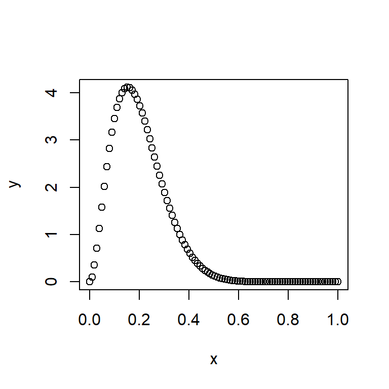

```r
mu <- 0.2
var <- 0.01
alpha <- mu * (((mu*(1-mu))/var) - 1)
beta <- (alpha*(1-mu))/mu
x <- seq(0, 1, length=100)
y <- dbeta(x, alpha, beta)
plot(x, y)
```

## b)

Histogram of a sample of 1000 random numbers from the above distribution.

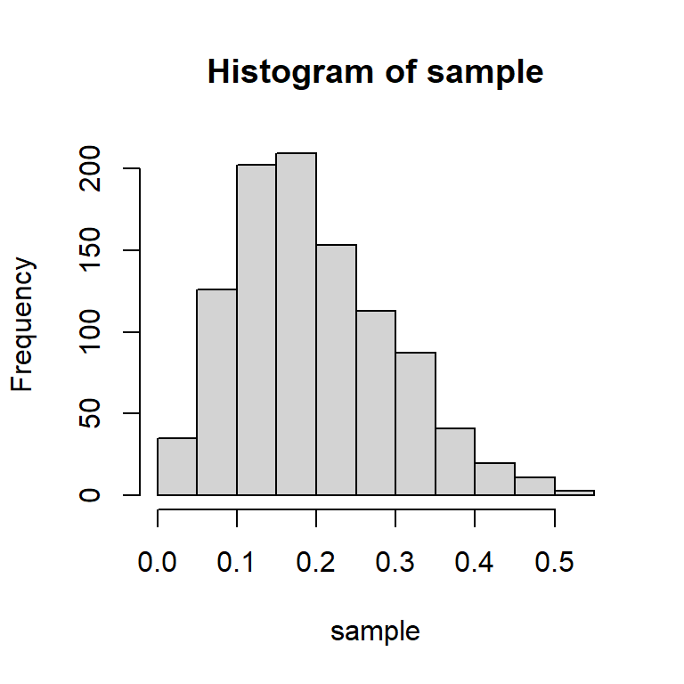

```r
n <- 1000
sample <- rbeta(n, alpha, beta)
hist(sample)
```

As we can see, the histogram of the samples that were drawn from the beta distribution follows the shape of the density function above.

## c)

Sample mean and variance from the drawn sample

```r
mu_bar <- mean(sample)
var_bar <- var(sample)
print(paste("Sample mean:", format(mu_bar)))
```

```
## [1] "Sample mean: 0.1972188"
```

```r
print(paste("Sample variance:", format(var_bar)))
```

```
## [1] "Sample variance: 0.009644253"
```

As we can see both values are approximately the same as the true values (i.e. $\mu$ = 0.2 and $\sigma^2$ = 0.01).

## d)

```r
print(paste("The central 95% probability interval of the distribution from the drawn samples is", format(quantile(sample, probs = 0.95))))
```

[output not shown]

# Exercise 3) Bayes’ theorem

The facts given by the researchers are the following:

- $P(positive|cancer)=0.98$,
- $P(negative|healthy) = 0.96$,
- $P(cancer)=0.001$

To simplify notation, we assume that not cancer equals being healthy. In order to know the recommendation that we would issue, we must compute what is the probability that a person has cancer given that the test predicts a positive result. We can compute this using the Bayes’ rule:
$$\begin{align}
P(cancer|positive) & =\frac{P(positive|cancer)P(cancer)}{P(positive)}\\
& = \frac{P(positive|cancer)P(cancer)}{P(positive|cancer)P(cancer)+P(positive|healthy)P(healthy)}\\
& = \frac{0.001*0.98}{0.98*0.001+0.04*0.999}\\
& = 0.0239
\end{align}$$
where
$$P(positive|healthy)=1-P(negative|healthy)=1-0.96=0.04$$
and
$$P(healthy)=1-P(cancer)=1-0.001=0.999.$$

Thus, we now know that for a random patient that is examined with this method, there is only a 2.4% probability of the patient actually having cancer when the test gives a positive result. This is very alarming because the consequences of a positive test are very drastic: medication, surgery or more testing. That would mean that most of the patients that would be given these treatments would not actually need them.

Based on this information, I would recommend decreasing the number of false positives (i.e. healthy predicted as positive), because that would increase $P(negative|healthy)$. This would mean that $P(positive|healthy)$ would decrease which is key to improve $P(cancer|positive)$ because 99.9% of the population do not have cancer, which gives this probability a large weight in the computation.

# Exercise 4) Bayes’ theorem

## a)

```r
boxes <- matrix(c(2,4,1,5,1,3), ncol = 2,
                dimnames = list(c("A", "B", "C"), c("red", "white")))
boxes
```

```
##   red white
## A   2     5
## B   4     1
## C   1     3
```

```r
p_red <- function(boxes) {
  p_A <- 0.4
  p_B <- 0.1
  p_C <- 0.5
  p <- p_A*boxes[1,1]/sum(boxes[1,]) + p_B*boxes[2,1]/sum(boxes[2,]) + p_C*boxes[3,1]/sum(boxes[3,])
  return(p)
}
p_red(boxes = boxes)
```

```
## [1] 0.3192857
```

## b)

To know the most probable box a red ball would be picked from, we need to compute

- $P(A|red)=\dfrac{P(A)*P(red|A)}{P(red)}$,
- $P(B|red)=\dfrac{P(B)*P(red|B)}{P(red)}$ and
- $P(C|red)=\dfrac{P(C)*P(red|C)}{P(red)}$.

The function definition would be the following

```r
p_box <- function(boxes) {
  p_A <- 0.4
  p_B <- 0.1
  p_C <- 0.5
  p_A.red <- p_A*boxes[1,1]/sum(boxes[1,])/p_red(boxes)
  p_B.red <- p_B*boxes[2,1]/sum(boxes[2,])/p_red(boxes)
  p_C.red <- p_C*boxes[3,1]/sum(boxes[3,])/p_red(boxes)
  return(c(p_A.red, p_B.red, p_C.red))
}
p_box(boxes = boxes)
```

```
## [1] 0.3579418 0.2505593 0.3914989
```

Looking at the output of the function we can conclude that if a red ball was picked, it most probably came from box C.

# Exercise 5) Bayes’ theorem

Knowing this, we can obtain the probability of Elvis being an identical twin given that he had a twin brother by
$$P(\text{identical twins | twin brother})=\dfrac{P(\text{identical twins & twin brother})}{P(\text{twin brother})}$$

This can be computed in R as

```r
p_identical_twin <- function(fraternal_prob, identical_prob) {
  p_it.and.tb <- identical_prob * 0.5
  p_ft.and.tb <- fraternal_prob * 0.5 * 0.5
  return(p_it.and.tb/(p_it.and.tb + p_ft.and.tb))
}
p_identical_twin(fraternal_prob = 1/150, identical_prob = 1/400)
```

```
## [1] 0.4285714
```